# 220606_trial_averaged_stimulus_response_dfs

Using `learning_mFISH` branch of `visual_behavior_analysis`

```python
import os
import numpy as np
import pandas as pd
import matplotlib.pyplot as plt

import seaborn as sns
sns.set_context('notebook', font_scale=1.5, rc={'lines.markeredgewidth': 2})
```

```python
%load_ext autoreload
%autoreload 2

%matplotlib inline
```

```python
import visual_behavior.data_access.loading as loading
```

### get learning mFISH pilot data from lims

```python
from allensdk.brain_observatory.behavior.behavior_project_cache import VisualBehaviorOphysProjectCache

cache = VisualBehaviorOphysProjectCache.from_lims()
```

```python
experiments_table = cache.get_ophys_experiment_table(passed_only=False)
experiments_table = experiments_table[experiments_table.project_code=='LearningmFISHTask1A']
```

```python
# what mice do we have?
print(experiments_table.mouse_id.unique())
```

```
['612764' '616502' '617911' '616505' '608368' '603892']
```

### get behavior sessions for special mouse

```python
behavior_sessions = cache.get_behavior_session_table()
```

```python
mouse_id = '603892' # bestest GAD2 mouse

# look at training history for this mouse
mouse_beh_data = behavior_sessions[behavior_sessions.mouse_id==mouse_id].sort_values(by='date_of_acquisition')
mouse_beh_data[['mouse_id', 'session_type', 'ophys_experiment_id', 'prior_exposures_to_image_set']]
```

| behavior_session_id | mouse_id | session_type | ophys_experiment_id | prior_exposures_to_image_set |
| --- | --- | --- | --- | --- |
| 1153004187 | 603892 | TRAINING_0_gratings_autorewards_15min | [1153099555, 1153099558, 1153099559, 115309956... | NaN |
| 1153543065 | 603892 | TRAINING_1_gratings | [1153662768, 1153662770, 1153662771, 115366277... | NaN |
| 1153793704 | 603892 | TRAINING_1_gratings | [1153920566, 1153920568, 1153920569, 115392057... | NaN |
| 1154034257 | 603892 | TRAINING_2_gratings_flashed | [1154288458, 1154288461, 1154288463, 115428846... | NaN |
| 1154262140 | 603892 | TRAINING_2_gratings_flashed | [1154369474, 1154369476, 1154369477, 115436947... | 0.0 |
| 1154472358 | 603892 | TRAINING_3_images_A_10uL_reward | [1154572286, 1154572288, 1154572289, 115457229... | 1.0 |
| 1155069835 | 603892 | TRAINING_3_images_A_10uL_reward | [1155282289, 1155282293, 1155282294, 115528229... | 2.0 |
| 1155426295 | 603892 | TRAINING_4_images_A_training | [1155524637, 1155524639, 1155524640, 115552464... | 3.0 |
| 1155634565 | 603892 | TRAINING_5_images_A_epilogue | [1155760201, 1155760204, 1155760205, 115576020... | 4.0 |
| 1155862755 | 603892 | TRAINING_5_images_A_handoff_ready | [1155949165, 1155949168, 1155949169, 115594917... | 5.0 |
| 1156064616 | 603892 | OPHYS_1_images_A | [1156751800, 1156751803, 1156751804, 115675180... | 6.0 |
| 1156620226 | 603892 | OPHYS_1_images_A | [1156776068, 1156776070, 1156776071, 115677607... | 7.0 |
| 1156884393 | 603892 | OPHYS_4_images_B | [1156990779, 1156990784, 1156990789, 115699079... | 0.0 |
| 1157136612 | 603892 | OPHYS_4_images_B | [1157244780, 1157244782, 1157244783, 115724478... | 1.0 |
| 1157372172 | 603892 | OPHYS_6_images_B | [1157477414, 1157477416, 1157477417, 115747741... | 2.0 |
| 1157575929 | 603892 | OPHYS_6_images_B | [1157708779, 1157708781, 1157708782, 115770878... | 3.0 |

### Get an ophys_experiment_id for one of the OPHYS_1_images_A sessions

```python
experiment_ids = experiments_table[experiments_table.behavior_session_id==1156064616].index.values
print(experiment_ids)
```

```
[1156751800 1156751803 1156751804 1156751806 1156751807 1156751809
 1156751810 1156751812]
```

```python
experiment_id = experiment_ids[0]
```

### load ophys dataset for this experiment

```python
dataset = cache.get_behavior_ophys_experiment(experiment_id)
```

[output not shown]

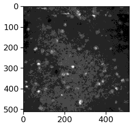

```python
plt.imshow(dataset.max_projection, cmap='gray')
```

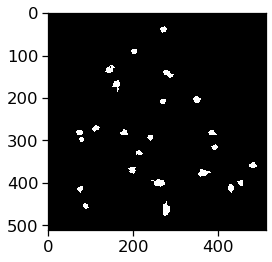

```python
plt.imshow(dataset.segmentation_mask_image, cmap='gray')
```

```python
dataset.dff_traces
```

| cell_specimen_id | cell_roi_id | dff |
| --- | --- | --- |
| 1157152946 | 1158443134 | [1.7956229820633356, 1.7855465485410342, 1.387... |
| 1167392300 | 1158443136 | [4.6408898183455385, 5.3055226028490585, 3.562... |
| 1157153040 | 1158443137 | [1.86498742629028, 1.3428503785057742, 1.00591... |
| 1157152999 | 1158443143 | [1.9320210116782677, 1.6513325990239662, 0.982... |
| 1167392307 | 1158443149 | [3.7695539807775593, 2.99196758556438, 2.92723... |
| 1157152989 | 1158443156 | [2.3044750898421107, 2.213317466747521, 1.5230... |
| 1157152952 | 1158443157 | [3.151107572899905, 2.0914650518660785, 2.2618... |
| 1157152967 | 1158443160 | [1.0118235004632778, 1.2237537530888847, 0.671... |
| 1157152838 | 1158443162 | [2.7104277552009055, 2.3025511271370673, 2.030... |
| 1157153085 | 1158443165 | [2.7264602911565303, 2.7098134227023056, 2.713... |
| 1157152854 | 1158443167 | [5.106896608499884, 4.086827308728901, 3.41907... |
| 1157152993 | 1158443174 | [1.4537320506408704, 1.6752925209526544, 1.326... |
| 1157152934 | 1158443178 | [0.7327016564004085, 0.9744498065718734, 0.735... |
| 1157152848 | 1158443182 | [2.552677441679444, 2.208307959680402, 1.72310... |
| 1157153002 | 1158443183 | [2.634607265350429, 2.030799524784848, 1.96075... |
| 1157152863 | 1158443188 | [2.5561709926073126, 2.20100917839999, 1.87895... |
| 1157152940 | 1158443190 | [0.5955948321878124, 0.6319295811135481, 0.362... |
| 1157152884 | 1158443194 | [1.7294731637146477, 1.1192965884821509, 1.230... |
| 1157152922 | 1158443195 | [1.5357136367662858, 1.1643502403866912, 0.908... |
| 1157153071 | 1158443197 | [1.6317978858771232, 1.4646353737712814, 0.990... |
| 1167392324 | 1158443199 | [2.0329831800484763, 1.6030086329648214, 1.548... |
| 1157152834 | 1158443205 | [2.3152891053205438, 1.65738012759169, 1.63434... |
| 1157152872 | 1158443208 | [2.2877347439296525, 2.7624630263400753, 2.398... |
| 1157152907 | 1158443223 | [2.227587737370925, 1.6921453294390625, 1.7207... |
| 1157152910 | 1158443226 | [0.8240220897816866, 1.0151355421925268, 1.034... |

### generate a dataframe of stimulus aligned traces for all cells in this dataset

This VBA helper function calls core functions in `mindscope_utilities`, including `mindscope_utilities.visual_behavior_ophys.data_formatting.get_stimulus_response_df` and `mindscope_utilities`, including `mindscope_utilities.visual_behavior_ophys.data_formatting.get_annotated_stimulus_presentations`

```python
stimulus_response_df = loading.get_stimulus_response_df(dataset, time_window=[-3, 3.1],
                                                        interpolate=True, output_sampling_rate=30,
                                                        data_type='dff', event_type='all')
```

```
generating response df
```

`stimulus_response_df` contains the stimulus aligned trace for every cell, for every stimulus presentation in the session, in a defined time window around stimulus onset

```python
stimulus_response_df.head()
```

|  | stimulus_presentations_id | cell_specimen_id | trace | trace_timestamps | mean_response | baseline_response | p_value_gray_screen | ophys_frame_rate | data_type | event_type | ... | engaged | engagement_state | time_from_last_change | pre_change | pre_omitted | post_omitted | licked | lick_on_next_flash | frame_rate | exclude_invalid_rois |
| --- | --- | --- | --- | --- | --- | --- | --- | --- | --- | --- | --- | --- | --- | --- | --- | --- | --- | --- | --- | --- | --- |
| 0 | 0 | 1157152834 | [-0.07069653720906108, -0.07207795680055795, -... | [-3.0, -2.966666666666667, -2.933333333333333,... | 0.052041 | -0.044729 | 0.2705 | 30 | dff | all | ... | False | disengaged | NaN | False | False | NaN | True | True | 30 | True |
| 1 | 0 | 1157152838 | [-0.05911301125485008, -0.02572556703543228, 0... | [-3.0, -2.966666666666667, -2.933333333333333,... | 0.093860 | -0.064363 | 0.0000 | 30 | dff | all | ... | False | disengaged | NaN | False | False | NaN | True | True | 30 | True |
| 2 | 0 | 1157152848 | [-0.04550768470120481, -0.04748771288143631, -... | [-3.0, -2.966666666666667, -2.933333333333333,... | 0.005496 | -0.036429 | 0.5260 | 30 | dff | all | ... | False | disengaged | NaN | False | False | NaN | True | True | 30 | True |
| 3 | 0 | 1157152854 | [0.0023735727893200442, -0.030777591201634084,... | [-3.0, -2.966666666666667, -2.933333333333333,... | 0.017920 | -0.145822 | 0.0449 | 30 | dff | all | ... | False | disengaged | NaN | False | False | NaN | True | True | 30 | True |
| 4 | 0 | 1157152863 | [-0.052457907697404965, -0.05176138603558173, ... | [-3.0, -2.966666666666667, -2.933333333333333,... | 0.049606 | -0.117652 | 0.2214 | 30 | dff | all | ... | False | disengaged | NaN | False | False | NaN | True | True | 30 | True |

5 rows × 54 columns

### plot average response for a few conditions

You can easily plot the population average response for all rows of the table (all stimulus conditions, all cells), or separating out just omissions or just changes

#### average everything in stim_response_df

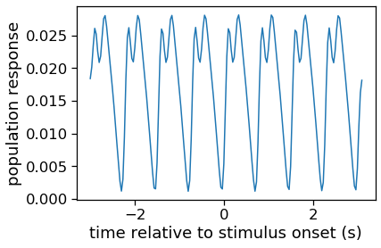

```python
plt.plot(stimulus_response_df.trace_timestamps.mean(), stimulus_response_df.trace.mean())
plt.xlabel('time relative to stimulus onset (s)')
plt.ylabel('population response')
```

#### just image changes

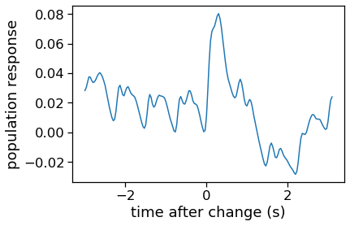

```python
# changes
traces = stimulus_response_df[stimulus_response_df.is_change==True].trace.values
timestamps = stimulus_response_df.trace_timestamps.values[0] # timestamps are shared across all rows
plt.plot(timestamps, traces.mean())
plt.xlabel('time after change (s)')
plt.ylabel('population response')
```

### across images

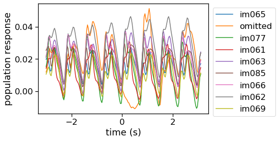

```python
# for each image
for image_name in stimulus_response_df.image_name.unique():
    traces = stimulus_response_df[stimulus_response_df.image_name==image_name].trace.values
    timestamps = stimulus_response_df.trace_timestamps.values[0] # timestamps are shared across all rows
    plt.plot(timestamps, traces.mean(), label=image_name)
plt.xlabel('time (s)')
plt.ylabel('population response')
plt.legend(bbox_to_anchor=(1,1))
```

There is a lot of metadata for each stimulus presentation

```python
stimulus_response_df.keys()
```

```
Index(['stimulus_presentations_id', 'cell_specimen_id', 'trace',
       'trace_timestamps', 'mean_response', 'baseline_response',
       'p_value_gray_screen', 'ophys_frame_rate', 'data_type', 'event_type',
       'interpolate', 'output_sampling_rate', 'response_window_duration',
       'start_time', 'stop_time', 'duration', 'image_name', 'image_index',
       'is_change', 'omitted', 'start_frame', 'end_frame', 'image_set',
       'licks', 'mean_running_speed', 'reward_rate_trials', 'epoch',
       'trials_id', 'change_time', 'go', 'catch', 'aborted', 'auto_rewarded',
       'hit', 'miss', 'false_alarm', 'correct_reject', 'response_time',
       'response_latency', 'reward_time', 'reward_volume', 'rewarded',
       'reward_rate_per_second', 'reward_rate', 'engaged', 'engagement_state',
       'time_from_last_change', 'pre_change', 'pre_omitted', 'post_omitted',
       'licked', 'lick_on_next_flash', 'frame_rate', 'exclude_invalid_rois'],
      dtype='object')
```

#### Plot population average for hit vs miss with sem

```python
import visual_behavior.visualization.utils as utils
```

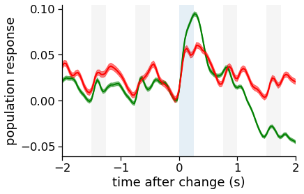

```python
# hits vs. misses
hit_traces = stimulus_response_df[(stimulus_response_df.is_change==True)&
                                 (stimulus_response_df.licked==True)].trace.values
miss_traces = stimulus_response_df[(stimulus_response_df.is_change==True)&
                                 (stimulus_response_df.licked==False)].trace.values
timestamps = stimulus_response_df.trace_timestamps.values[0] # timestamps are shared across all rows

fig, ax = plt.subplots()
ax = utils.plot_mean_trace(hit_traces, timestamps, legend_label='hit', color='g', xlim_seconds=[-2, 2], ax=ax)
ax = utils.plot_mean_trace(miss_traces, timestamps, legend_label='miss', color='r', xlim_seconds=[-2, 2], ax=ax)
ax = utils.plot_flashes_on_trace(ax, timestamps, change=True)
ax.set_xlabel('time after change (s)')
ax.set_ylabel('population response')
```

### stimulus_response_df also works for behavior timeseries

check the documentation for what `data_type` values are accepted

```python
help(loading.get_stimulus_response_df)
```

```
Help on function get_stimulus_response_df in module visual_behavior.data_access.loading:

get_stimulus_response_df(dataset, time_window=[-3, 3.1], interpolate=True, output_sampling_rate=30, data_type='filtered_events', event_type='all', load_from_file=False, exclude_invalid_rois=True)
    load stimulus response df using mindscope_utilities and merge with stimulus_presentations that has trials metadata added
    inputs:
        dataset: BehaviorOphysExperiment instance
        time_window: window over which to extract the event triggered response around each stimulus presentation time
        interpolate: Boolean, whether or not to interpolate traces
        output_sampling_rate: sampling rate for interpolation, only used if interpolate is True
        data_type: which timeseries to get event triggered responses for
                    options: 'filtered_events', 'events', 'dff', 'running_speed', 'pupil_diameter', 'lick_rate'
        event_type: how to filter stimulus presentations before creating table
                    options: 'all', 'omissions', 'changes'
        exclude_invalid_rois: Bool, if True, only 'valid' ROIs will be returned. If False, all ROIs including 'invalid' ROIs will be returned.
                                Only applies if the dataset object that is provided was loaded from lims (not via AWS NWB files, which only have 'valid' ROIs in them)
                                Note that including invalid ROIs will result in some cell traces being NaNs because traces are not computed for some types of invalid ROIs
```

#### population average running speed for changes

```python
# use a different data_type, and set event_type to just get changes
running_traces = loading.get_stimulus_response_df(dataset, time_window=[-2, 2.1],
                                                        interpolate=True, output_sampling_rate=30,
                                                        data_type='running_speed', event_type='changes')
```

```
generating response df
```

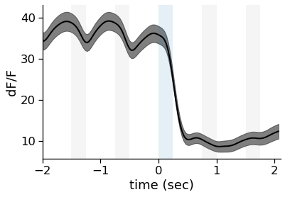

```python
fig, ax = plt.subplots()
timestamps = running_traces.trace_timestamps.values[0]
traces =  running_traces.trace.values
ax = utils.plot_mean_trace(traces, timestamps, xlim_seconds=[-2, 2.1], ax=ax)
ax = utils.plot_flashes_on_trace(ax, timestamps, change=True)
```